# 621-FinalProject

# Model Selection

| Model | Precision | Recall | AIC | AUC | F-score | Accuracy | Error |
| --- | --- | --- | --- | --- | --- | --- | --- |
| Bin. Log. w/ Original Data | 0.68 | 0.11 | 1939.25 | 0.71 | 0.195 | 0.86 | 0.14 |
| Bin. Log. w/ Modified Data | 0.67 | 0.02 | 1507.5 | 0.7 | 0.033 | 0.87 | 0.13 |
| Step AIC Bin. Log. w/ Original Data | 0.7 | 0.11 | 1928.55 | 0.71 | 0.196 | 0.86 | 0.14 |
| Step AIC Bin. Log. w/ Modified Data | 0.67 | 0.02 | 1496.61 | 0.69 | 0.033 | 0.87 | 0.13 |

*Table 6: Model metrics for binary logistic regression models*

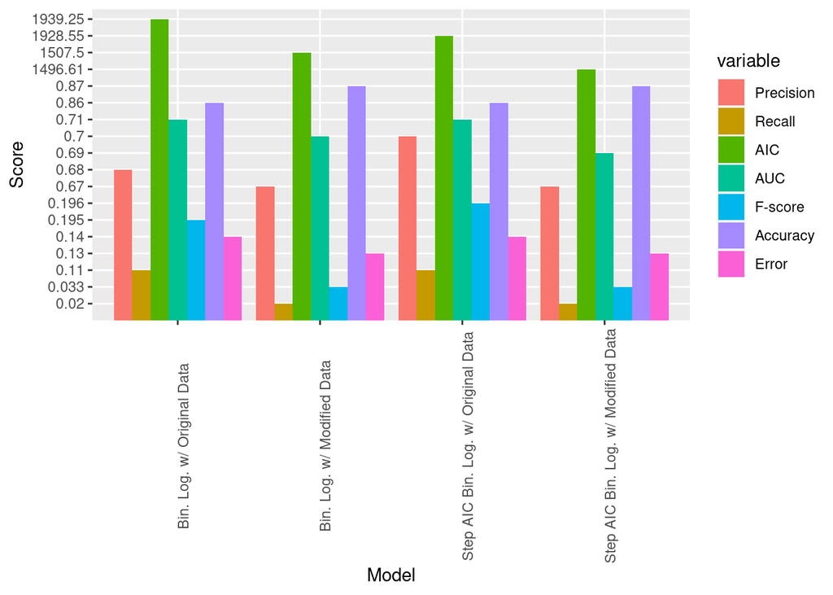

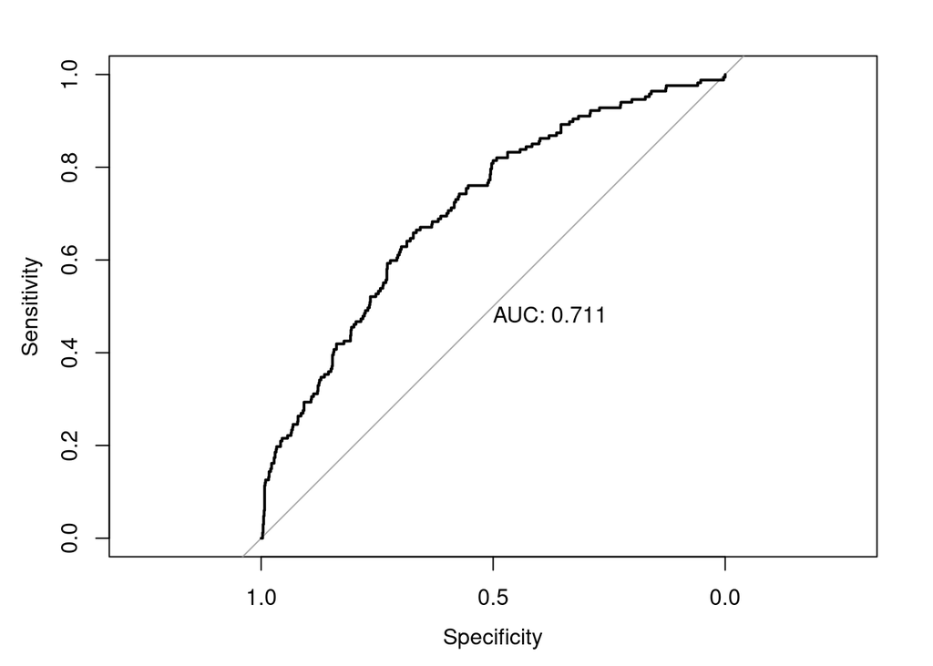

# Discussion and Conclusions

In this paper, 4 different binary logistic regression models were generated in order to predict the 10-year risk of chronic heart disease. The results from the analysis carried out in this report indicate that the transformation of the skewed variables to a normal distribution and the removal of outliers resulted in worse model performance when comparing the metrics to these models and the models that used the original unaltered dataset. With that being said, the AUC’s for all of the models were relatively the same. The final model that was selected in order to predict the 10-year risk of chronic heart disease was the best performing and the most parsimonious. We were able to test the validity of this particular model from when the data was split into testing and training datasets.

# References

Center for Drug Evaluation and Research. (2021a, January 21). High Blood Pressure– Understanding the Silent Killer. U.S. Food And Drug Administration. https://www.fda.gov/drugs/special-features/high-blood-pressure-understanding-silent- killer

Center for Drug Evaluation and Research. (2021b, January 21). High Blood Pressure– Understanding the Silent Killer. U.S. Food And Drug Administration. https://www.fda.gov/drugs/special-features/high-blood-pressure-understanding-silent- killer

Framingham Study | Boston Medical Center. (n.d.). https://www.bmc.org/stroke-and- cerebrovascular-center/research/framingham-study

High cholesterol - Symptoms and causes. (2021, July 20). Mayo Clinic. https://www.mayoclinic.org/diseases-conditions/high-blood-cholesterol/symptoms- causes/syc-20350800

Liu, J., MD. (2022a, July 19). What’s a dangerous heart rate? What’s a Dangerous Heart Rate? | Ohio State Health & Discovery. Retrieved December 5, 2022, from https://health.osu.edu/health/heart-and-vascular/what-is-dangerous-heart-rate

NCBI - WWW Error Blocked Diagnostic. (n.d.). https://www.ncbi.nlm.nih.gov/pmc/articles/PMC4159698/

NHS website. (2022, July 4). Low blood pressure (hypotension). nhs.uk. https://www.nhs.uk/conditions/low-blood-pressure-hypotension/

Tachycardia: Symptoms, Causes & Treatment. (n.d.). Cleveland Clinic. https://my.clevelandclinic.org/health/diseases/22108-tachycardia

# Appendix